# Part_iii_Classification_C

Yijun_Zhou

4/25/2022

# overview of Part_iii_Classification_C

• You must make predictions with your 2 selected generalized linear models in order to visualize the trends of the event probability with respect to the inputs.  
• You may use non-Bayesian or Bayesian models for the predictions.  
• You must decide which inputs/features you wish to visualize the trends with respect to.  
• You must visualize your predictive trends using the following style:  
The primary input should be used as the x-aesthetic in a graphic.  
The secondary input should be used as a facet variable – it is recommended to use 4 to 6 unique values if your secondary input is a continuous variable.  
• You must decide what values to use for the remaining inputs.  
• You MUST include the predicted mean event probability and the confidence interval whether you use non- Bayesian or Bayesian models.  
• You MUST state if the predictive trends are consistent between the 2 selected generalized linear models.  
### load packages

```r
library(tidyverse)
library(caret)
```

```r
library(cowplot)
library(coefplot)
```

## read data set

```r
df_all <- readr::read_csv("final_project_train.csv", col_names = TRUE)
df_all %>%select(-rowid,-response)%>%glimpse
```

```
## Rows: 677
## Columns: 36
## $ region   <chr> "XX", "XX", "XX", "XX", "XX", "XX", "XX", "XX", "XX", "XX", "…
## $ customer <chr> "B", "B", "B", "B", "B", "B", "B", "B", "B", "B", "B", "B", "…
## $ xb_01    <dbl> 4.000000, 1.000000, 2.000000, 2.520000, 2.548387, 3.071429, 3…
## $ xb_02    <dbl> 4, 1, 2, 11, 6, 6, 10, 12, 9, 10, 8, 10, 10, 8, 6, 10, 13, 10…
## $ xb_03    <dbl> 4, 1, 2, -6, -1, 1, -4, -4, -2, -4, -2, -2, -2, -4, 1, -4, -3…
## $ xn_01    <dbl> 3.0000000, 2.0000000, 2.0000000, 1.5333333, 0.8387097, 1.8571…
## $ xn_02    <dbl> 3, 2, 4, 9, 3, 8, 6, 10, 10, 4, 6, 8, 9, 5, 7, 12, 12, 6, 6, …
## $ xn_03    <dbl> 3, 2, 0, -3, -4, -2, -5, -6, -3, -5, -3, -6, -4, -3, 0, -5, -…
## $ xa_01    <dbl> 12.000000, 3.000000, 9.000000, 7.080000, 6.451613, 6.857143, …
## $ xa_02    <dbl> 12, 3, 9, 29, 17, 18, 24, 27, 20, 19, 15, 24, 24, 15, 14, 26,…
## $ xa_03    <dbl> 12, 3, 9, -7, -2, 2, -9, -5, -3, -3, -1, 1, -2, -3, 3, -4, -5…
## $ xb_04    <dbl> 1.3333333, 1.0000000, 1.0000000, 0.8950476, 1.2247312, 1.1857…
## $ xb_05    <dbl> 1.3333333, 1.0000000, 1.0000000, -2.0000000, -0.5000000, 0.00…
```

[output cut: 23 more lines]

## You must make predictions with your 2 selected generalized linear models in order to visualize the trends of the event probability with respect to the inputs.

```r
model_3<-readr::read_rds('c_fit_glm_all.rds')
model_3
```

```
## Generalized Linear Model
##
## 677 samples
##  35 predictor
##   2 classes: 'event', 'non_event'
##
## Pre-processing: centered (43), scaled (43)
## Resampling: Cross-Validated (5 fold, repeated 3 times)
## Summary of sample sizes: 541, 541, 542, 542, 542, 542, ...
## Resampling results:
##
##   ROC        Sens       Spec
##   0.8355152  0.4361026  0.930303
```

```r
model_2<-readr::read_rds('c_fit_glm_continuous_only.rds')
model_2
```

```
## Generalized Linear Model
##
## 677 samples
##  33 predictor
##   2 classes: 'event', 'non_event'
##
## Pre-processing: centered (33), scaled (33)
## Resampling: Cross-Validated (5 fold, repeated 3 times)
## Summary of sample sizes: 542, 541, 542, 542, 541, 542, ...
## Resampling results:
##
##   ROC        Sens       Spec
##   0.8199469  0.3673846  0.9406061
```

## You must decide which inputs/features you wish to visualize the trends with respect to.

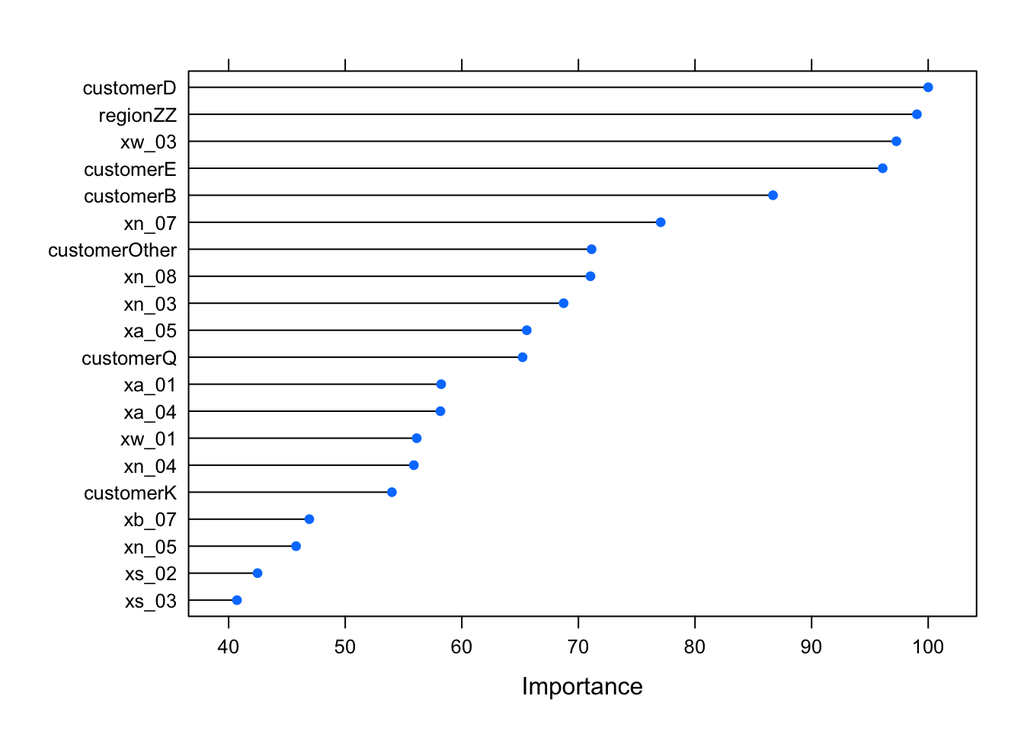

```r
varImp(model_3)%>%plot(top=20)
```

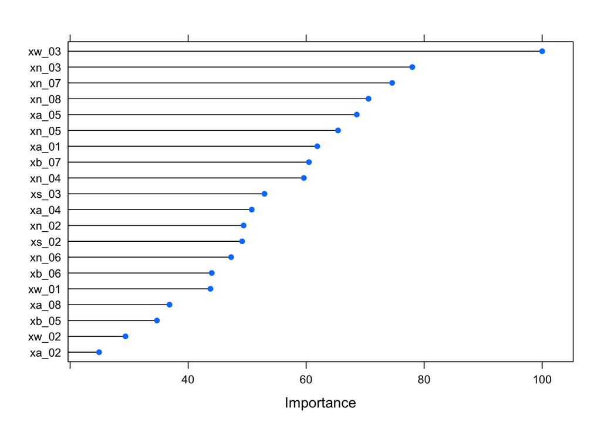

```r
varImp(model_2)%>%plot(top=20)
```

```r
make_test_input_list <- function(var_name, top_4_inputs, all_data)
{
  xvar <- all_data %>% select(all_of(var_name)) %>% pull()
  if (var_name %in% top_4_inputs[1:2]){
    # use 25 unique values between the min/max values
    xgrid <- seq(min(xvar), max(xvar), length.out = 25)
  } else if (var_name %in% top_4_inputs[3:4]){
    # specify quantiles to use
    xgrid <- quantile(xvar, probs = c(0.05, 0.25, 0.5, 0.75, 0.95), na.rm = TRUE)
    xgrid <- as.vector(xgrid)
  } else {
    # set to their median values
    xgrid <- median(xvar, na.rm = TRUE)
  }
}
make_test_input_grid <- function(all_input_names, top_4_inputs, all_data)
{
  test_list <- purrr::map(all_input_names,

                         make_test_input_list,
                          top_4_inputs = top_4_inputs,
                          all_data = all_data)

  expand.grid(test_list,
              KEEP.OUT.ATTRS = FALSE,
              stringsAsFactors = FALSE) %>%
    purrr::set_names(all_input_names)
}
input_names_3 <- df_all %>% dplyr::select(-outcome) %>% names()
top_ranked_inputs_3 <- (varImp(model_3))$importance %>%
  tibble::rownames_to_column("var_name") %>%
  arrange(desc(Overall)) %>%
  slice(1:4) %>%
  pull(var_name)
input_names_2 <- df_all %>% dplyr::select(-outcome,-region,-customer) %>% names()
top_ranked_inputs_2 <- (varImp(model_2))$importance %>%
  tibble::rownames_to_column("var_name") %>%
  arrange(desc(Overall)) %>%
  slice(1:4) %>%
  pull(var_name)
top_ranked_inputs_3
```

```
## [1] "customerD" "regionZZ"  "xw_03"     "customerE"
```

```r
top_ranked_inputs_2
```

```
## [1] "xw_03" "xn_03" "xn_07" "xn_08"
```

```r
viz_grid_3 <- make_test_input_grid(input_names_3, top_ranked_inputs_3, df_all)
viz_grid_2<-make_test_input_grid(input_names_2,top_ranked_inputs_2,df_all)
```

## You must visualize your predictive trends using the following style:

```r
pred_glm_3<-predict(model_3,viz_grid_3,type='prob')
```

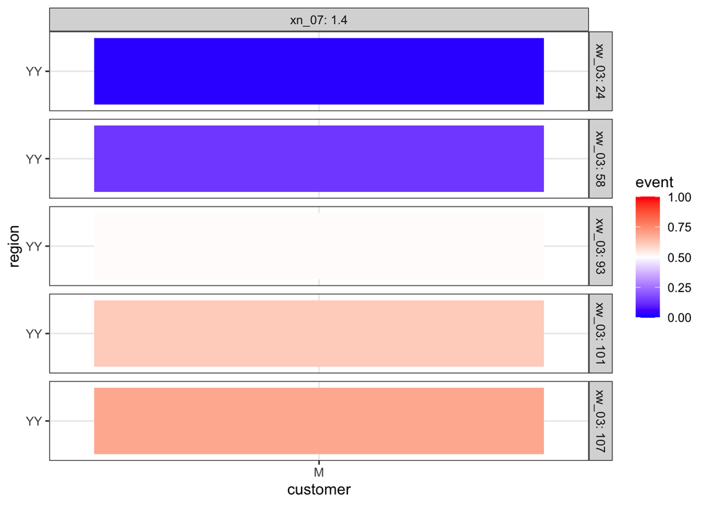

```r
viz_grid_3 %>%
  bind_cols(pred_glm_3) %>%
  ggplot(mapping = aes(x = customer, y = region)) +
  geom_raster(mapping = aes(fill = event)) +
  facet_grid( xw_03 ~xn_07, labeller = "label_both") +
  scale_fill_gradient2(limits = c(0, 1),
                       low = 'blue', high = 'red', mid = 'white',
                       midpoint = 0.5) +
  theme_bw()
```

```r
pred_glm_2<-predict(model_2,viz_grid_2,type='prob')
```

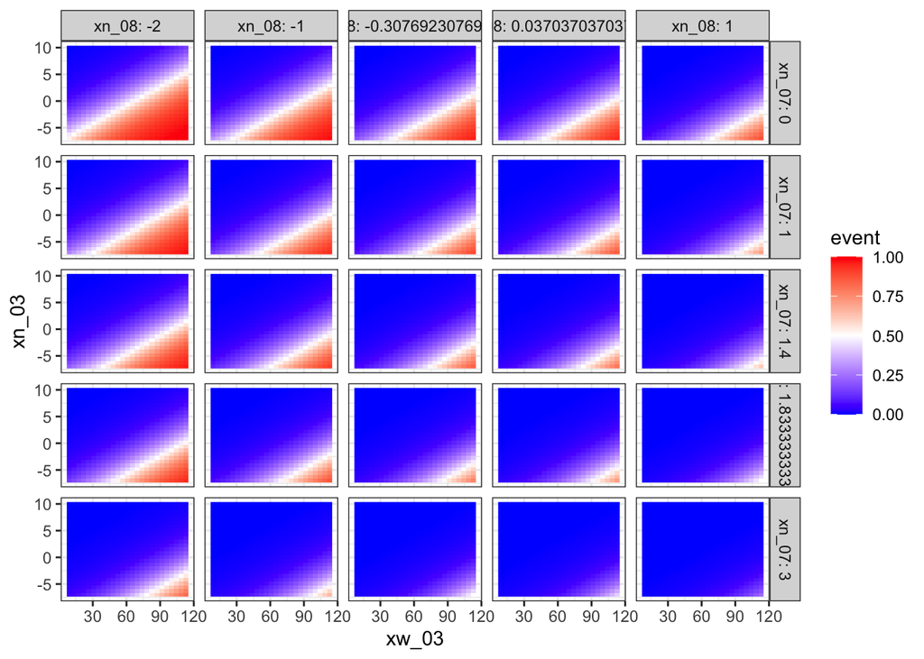

```r
viz_grid_2 %>%
  bind_cols(pred_glm_2) %>%
  ggplot(mapping = aes(x = xw_03, y = xn_03)) +
  geom_raster(mapping = aes(fill = event)) +
  facet_grid( xn_07 ~xn_08, labeller = "label_both") +
  scale_fill_gradient2(limits = c(0, 1),
                       low = 'blue', high = 'red', mid = 'white',
                       midpoint = 0.5) +
  theme_bw()
```

## You MUST state if the predictive trends are consistent between the 2 selected generalized linear models.

Based on the results of model 3, we can find that the probability of event increases as the value of xw_03 increases;  
Based on the results of model 2, we can find that the probability of event increases as the value of xw_03 increases; the probability of event increases as the value of xn_03 decreases; the probability of event increases as the value of xn_07 decreases; and the probability of event increases as the value of xn_08 decreases.  
In conclusion, based on the analysis of the predictive trends of the top inputs, since xw_03 is in both linear models and the predictive trends of both models are increasing with xw_03’s increasing, we can make a conclusion that the predictive trends are consistent between the 2 selected generalized linear models.